# Fundamentos de Pesquisa em Ciência da Computação 2

# 4. A duração da sessão é aproximadamente o tempo entre o primeiro e o último evento de uma sessão. Escolha uma variável do conjunto de dados e descreva sua relação com o tamanho da sessão. Visualize o relacionamento.

Optou-se por comparar o tempo de sessão com a quantidade de buscas em uma mesma sessão. Interessante notar que a quantidade de buscas efetuadas para aqueles que utilizaram o algoritmo de busca A é muito maior que os que utilizaram o algortimo B. Talvez esse efeito se deve a algum fator ineficiente do algorítmo (delay, resultados errados, etc)

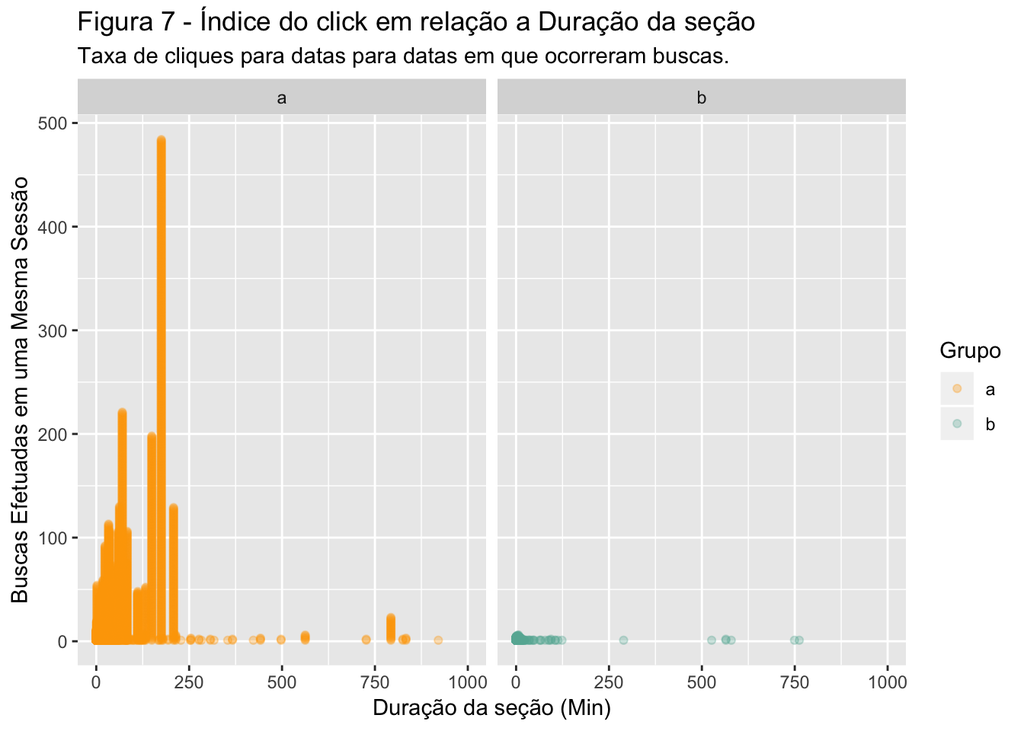

```r
search_by_min = buscas %>%
  mutate(session_length_min = session_length/60)

search_by_min %>%
  ggplot(mapping = aes(x = session_length_min, y = search_index, color=group)) +
  scale_color_manual(values=c("orange", "#68B3A2")) +
  geom_point(alpha = 0.3, na.rm = TRUE) +
  scale_x_continuous(limits=c(0,1000)) +
  facet_wrap(~group)+
  labs(
      title = "Figura 7 - Índice do click em relação a Duração da seção",
      x = "Duração da seção (Min)",
      y = "Buscas Efetuadas em uma Mesma Sessão",
      subtitle = "Taxa de cliques para datas para datas em que ocorreram buscas.",
      color = "Grupo"
      )
```

## **4.** Resultados e Conclusões

Sabe-se que a média geral de clicks é maior para o grupo A. Assim, como o número de ocorrências é maior para esse grupo (Figura 2), visto isso, aparentemente o algoritmo do grupo A foi utilizado com muito mais intensidade ou é mais eficiente de fato.

Por fim, relacionamos a variável duração da sessão com a quantidade de buscas efetuadas na sessão e observamos que, para o grupo B a sequencia de buscas por sessão é bem menor do que para o grupo A, além de sessões com pouca duração (Figura 7).